# Statistical Learning Final Project

# 1 Introduction

For this assignment we will be analyzing and creating models based on housing data of a fictional Australian city named “Ken-Behrnia”, which was provided in the class files. Since the training data is already labeled we know we will be mainly focusing on implementing Supervised Machine Learning models. Furthermore, looking into the instruction for this assignment the aim of this assingment is predicting two different variables (price, sent). Since price is a continuous variable all models relating to price can be found under the Regression Chapter of the assignment (Chapter 4), likewise sent is a categorical variable and all models relating to sent can be found under the Classification chapter of this assignment (Chapter 3).

# 2 Exploratory Data Analysis

## 2.1 Data Cleaning

```
## 'data.frame':    30000 obs. of  15 variables:
##  $ id        : int  1 2 3 4 5 6 7 8 9 10 ...
##  $ price     : num  1.62 1.234 0.969 -0.156 -0.918 ...
##  $ sent      : int  1 1 1 0 0 1 1 1 0 0 ...
##  $ cond      : num  1.25 2.63 1.28 2.52 0.92 ...
##  $ year      : int  5 2 9 3 5 11 2 12 NA 4 ...
##  $ built     : int  1 2 2 2 4 10 2 8 2 10 ...
##  $ lat       : num  0.214 1.044 0.607 0.196 -0.538 ...
##  $ lon       : num  0.0871 0.1758 0.0777 0.1042 0.2372 ...
##  $ sq.m.h    : int  271 400 270 130 229 471 149 567 243 248 ...
##  $ sq.m.block: int  1686 805 497 446 937 1242 48085 1115 556 1255 ...
##  $ sq.m.pool : int  21 0 0 0 0 64 0 68 0 42 ...
##  $ reno      : int  0 0 0 0 0 0 0 0 0 0 ...
##  $ bedrooms  : int  3 5 2 5 5 4 3 4 4 3 ...
##  $ bathrooms : int  3 4 3 2 2 4 2 4 3 3 ...
##  $ environ   : int  1 1 1 1 2 0 0 1 2 1 ...
```

Loading in our data lets begin by renaming certain columns to make it easier to interpret models which are created from the data. In particular lets change: * (sq.m.h -> LivingSpace) * (sq.m.block -> LotSize) * (sq.m.pool -> Pool)

Additionally we can remove the “id” column from our data as it shouldn’t have any influence on our model and may lead to an incorrect fitting of the model to the data set.Furthermore currently all columns are identified as a numeric type and this is incorrect.

## 2.2 Testing/Training Split

Next lets split our data into training and validation sets. I have decided to do this step early to avoid any accidental data between the two different sets. This is particularly important as evaluating a model on data it has been trained on would lead to a bias score, this is why its important to evaluate your model performance on previously unseen data (validation set) as in sample validation guarantees overfitting.

Additionally I am also ordering the dataset randomly to ensure that the training set and test set are both random samples and that any biases in the ordering of the dataset are not retained in the samples we take for training and testing of the models.

```r
nrow(train_t)/nrow(test_t)
```

```
## [1] 4
```

Here we can see that our training data has been split into an 80/20 pattern for training and validating models.

## 2.3 Missing Data

> The best way to deal with missing data is to not have any. -Statistician Gertrude Mary Cox

Although if we are working with real world data then we are bound to have missing data whether due to human error during the data collection process or because we are merging data from different databases(sources). There are two ways to deal with missing data we can either remove data rows which contain any missing values, or we can impute the missing values, although it should be noted bad imputation can lead to poor estimates and decisions.

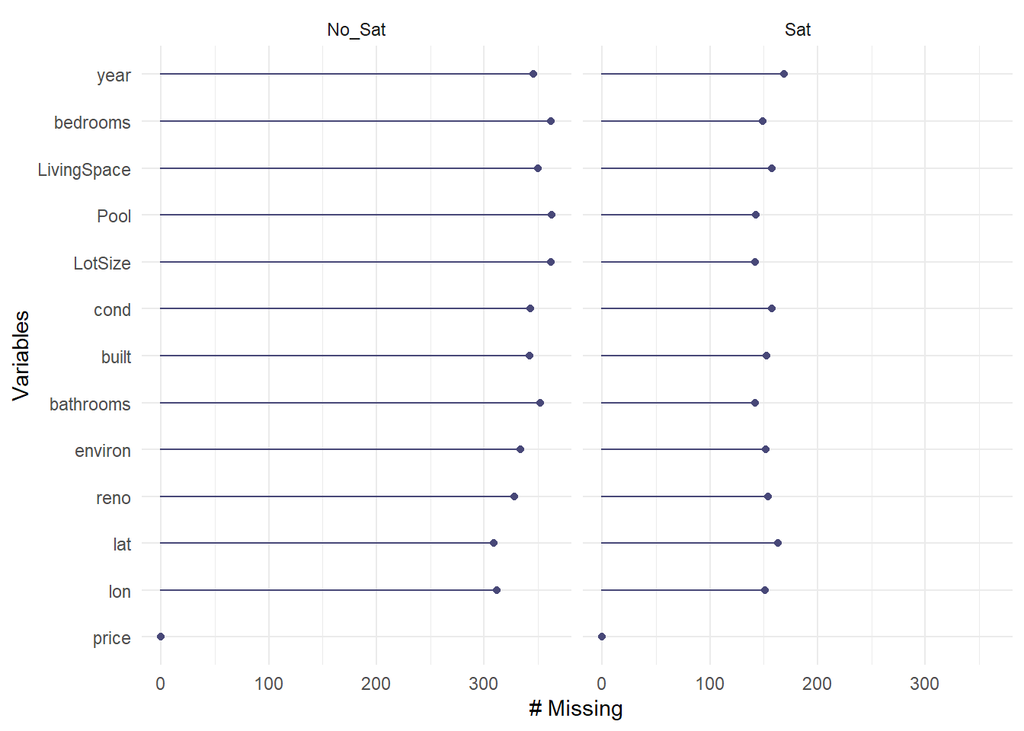

Next lets look at missing data dependence

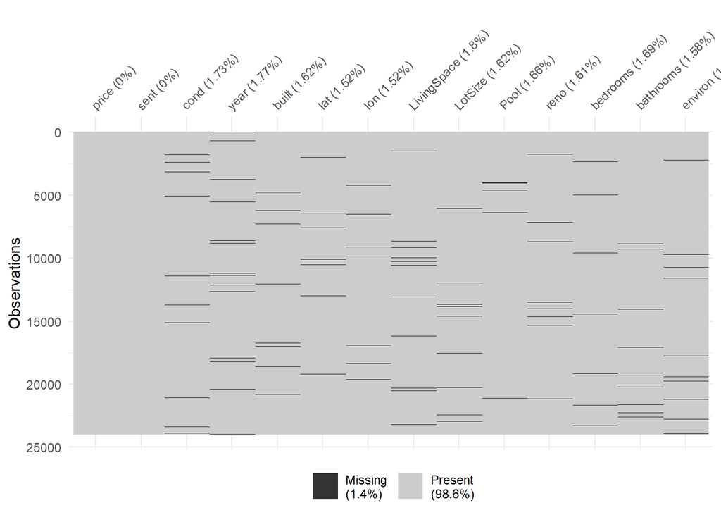

I don’t see any pattern in the missingness of data so we can classify this at MCAR. The missingness has no association with any data we have observed or not observed. Since this is MCAR it is generally recommended that we impute our data, and to not delete unless there is less than 5% data loss (Rule of thumb not sure where I learnt it from).

During class we learnt about single imputation using mean and mode, but I don’t think either of these are an appropriate way to fill in our missing data as say for example a house bought in Braddon with 2 bathrooms and 3 bedrooms will cost a lot higher than the same “size” house in a different city, therefore in my opinion performing KNN imputation seems most appropriate given the data we are trying to impute.

In order to do kNN we need a way to measure distance between two observations, for numeric variable we use eculudian distance for factor variables we use Manhattan distance and for categorical distance we use hamming distance.

The knn algorithm loops over variables imputing them one by one each time distances between observations are calculated therefore if the column chosen had a lot of missing values then distance calculation for second variable will have been computed using a lot of imputed values. Therefore it is good practice to sort variable in asending order by the number of missing values before running the kNN algorithm.

## 2.4 Data PreProcessing

|  | vars | n | mean | sd | median | trimmed | mad | min | max | range | skew | kurtosis | se |
| --- | --- | --- | --- | --- | --- | --- | --- | --- | --- | --- | --- | --- | --- |
| price | 1 | 24000 | 0.24529950 | 1.1366955 | 0.1395992 | 0.18531732 | 1.10651056 | -3.430332 | 6.938294 | 10.3686262 | 0.57177852 | 0.61754203 | 0.0073373381 |
| sent* | 2 | 24000 | 1.24779167 | 0.4317392 | 1.0000000 | 1.18473958 | 0.00000000 | 1.000000 | 2.000000 | 1.0000000 | 1.16828786 | -0.63512993 | 0.0027868645 |
| lon | 3 | 24000 | -0.07906709 | 1.1331920 | 0.2094908 | 0.21893666 | 0.12797370 | -4.053626 | 1.110181 | 5.1638074 | -3.18414168 | 8.28455397 | 0.0073147230 |
| lat | 4 | 24000 | -0.04640066 | 1.0723838 | 0.2120932 | 0.13945616 | 0.78990875 | -3.165878 | 1.234218 | 4.4000961 | -1.68340314 | 2.61849910 | 0.0069222078 |
| bathrooms | 5 | 24000 | 2.15233333 | 0.8246653 | 2.0000000 | 2.11250000 | 0.00000000 | 0.000000 | 9.000000 | 9.0000000 | 0.73108814 | 1.51285046 | 0.0053231918 |
| reno* | 6 | 24000 | 1.11775000 | 0.3223186 | 1.0000000 | 1.02218750 | 0.00000000 | 1.000000 | 2.000000 | 1.0000000 | 2.37177810 | 3.62548242 | 0.0020805575 |
| built* | 7 | 24000 | 5.33570833 | 2.8674932 | 5.0000000 | 5.30208333 | 2.96520000 | 1.000000 | 10.000000 | 9.0000000 | 0.06912652 | -1.21669039 | 0.0185095893 |
| LotSize | 8 | 24000 | 2.86819765 | 0.1107639 | 2.8706141 | 2.87017256 | 0.07974543 | 2.416882 | 3.252599 | 0.8357171 | -0.28962762 | 1.61713185 | 0.0007149781 |
| environ | 9 | 24000 | 1.20016667 | 0.6875340 | 1.0000000 | 1.12531250 | 0.00000000 | 0.000000 | 5.000000 | 5.0000000 | 1.54015776 | 3.85724052 | 0.0044380129 |
| Pool | 10 | 24000 | 25.60695833 | 27.4920362 | 21.0000000 | 22.41000000 | 31.13460000 | 0.000000 | 262.000000 | 262.0000000 | 0.71210935 | 0.08717622 | 0.1774603303 |

[output cut: 4 more lines]

To summarize, generally if the distribution of data is skewed to the left a pattern of (mean < median < mode) can be seen likewise for right skew aswell.But this R function makes it much simpler to determine which columns need to be transformed.In my opinion the variables lon,lotsize are the most heavily skewed and need to be transformed.

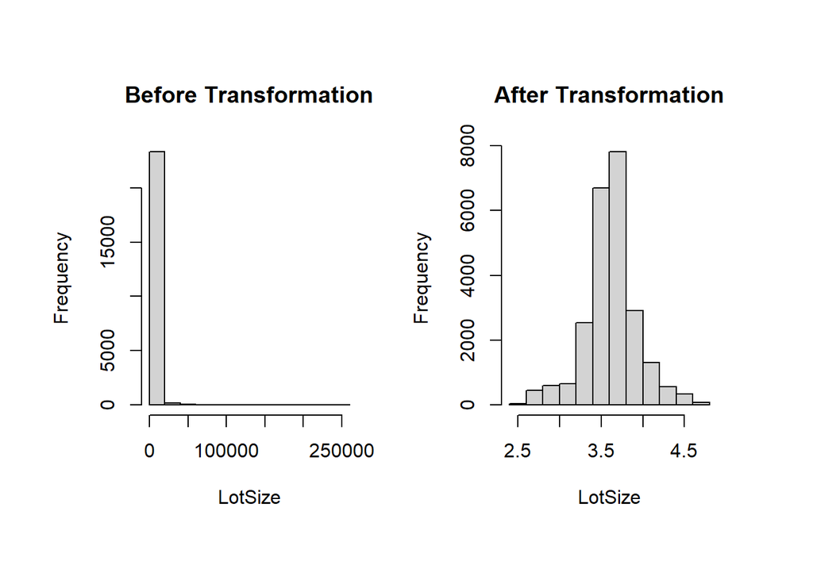

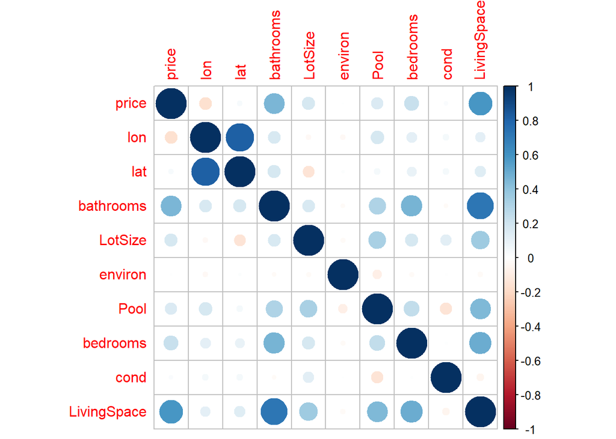

There is some apparent collinearity between lattitude/longitute which I supposed is to be expected as those values should logically be linked together. Might be beneficial to create a new variable which has bins of (lat/lon) pairs, to create a street area code. Additionally all data will be centered and scaled all to make it easier to work with different models.

```r
rg_train <- train_imp[-2]
rg_test <- test_imp[-2]

cm_train <- train_imp[-1]
cm_test <- test_imp[-1]

preProcValues_r <- preProcess(rg_train, method = c("center", "scale"))
trainTransformed_r <- predict(preProcValues_r, rg_train)
testTransformed_r <- predict(preProcValues_r, rg_test)

preProcValues <- preProcess(cm_train, method = c("center", "scale"))
trainTransformed <- predict(preProcValues, cm_train)
testTransformed <- predict(preProcValues, cm_test)
```

# 3 Classification Models

The goal of classification models is to map the given input data into different categories. For our particular model we will be focusing on binary classification

$$\{\operatorname{sent} \} \in \mathcal{Y} \mid\{1,0\} \in \operatorname{sent}$$

The evaluation metric that we will be using for the Classification Models is the correct classification rate(Accuracy). But we should also be mindful of the sensitivity vs specificity trade off. Wherein sensitivity tells use what percentage of samples where correctly identified as very satisfied classified(TP/(TP+FN)),while specificity tells us what percentage not satisfied where correctly identified (TN/(TN+FP)).

```
## No_Sat    Sat
##  18053   5947
```

Keeping these things in mind it is also important to talk about the apparent “class imbalance” in our training data. Looking summary statistics we can see that one of our class is dominating the other, this is problematic because if we build a model that classifies everything as belonging to class 0 then given our training data it would have an accuracy of almost 75%!.

One potential method for combating the disparity in the frequency of the different classes would be to subsample our data. For example we could “down sample” our data wherein the function randomly subsets our data to match the “least prevalent class” or alternatively we would “up sample” where we randomly sample the minority class (with replacement) to be the same size as the majority class.

Additionally I will we doing 5 fold cross validation of all models to improve the model accuracy and limit uncertainty.

## 3.1 k-Nearest Neighbors

The first of the classification models we are going to explore is KNN. KNN uses a “distance” measure to find the distance from the given object to all other nearest objects. It then uses a consensus model where it “asks” its k nearest neighbors what class they belong too, and the majority class is chosen as the output.

```
## Confusion Matrix and Statistics
##
##           Reference
## Prediction No_Sat  Sat
##     No_Sat   1766  446
##     Sat      2742 1046
##
##                Accuracy : 0.4687
##                  95% CI : (0.456, 0.4814)
##     No Information Rate : 0.7513
##     P-Value [Acc > NIR] : 1
##
##                   Kappa : 0.0613
##
##  Mcnemar's Test P-Value : <2e-16
##
##             Sensitivity : 0.3917
##             Specificity : 0.7011
##          Pos Pred Value : 0.7984
##          Neg Pred Value : 0.2761
##              Prevalence : 0.7513
##          Detection Rate : 0.2943
##    Detection Prevalence : 0.3687
##       Balanced Accuracy : 0.5464
##
##        'Positive' Class : No_Sat
##
```

## 3.2 Logistic Regression with Regularization

```
## Confusion Matrix and Statistics
##
##           Reference
## Prediction No_Sat  Sat
##     No_Sat   3515  404
##     Sat       993 1088
##
##                Accuracy : 0.7672
##                  95% CI : (0.7563, 0.7778)
##     No Information Rate : 0.7513
##     P-Value [Acc > NIR] : 0.002252
##
##                   Kappa : 0.4496
##
##  Mcnemar's Test P-Value : < 2.2e-16
##
##             Sensitivity : 0.7797
##             Specificity : 0.7292
##          Pos Pred Value : 0.8969
##          Neg Pred Value : 0.5228
##              Prevalence : 0.7513
##          Detection Rate : 0.5858
##    Detection Prevalence : 0.6532
##       Balanced Accuracy : 0.7545
##
##        'Positive' Class : No_Sat
##
```

## 3.3 Support Vector Machines

```
## Confusion Matrix and Statistics
##
##           Reference
## Prediction No_Sat  Sat
##     No_Sat   4327  972
##     Sat       181  520
##
##                Accuracy : 0.8078
##                  95% CI : (0.7976, 0.8177)
##     No Information Rate : 0.7513
##     P-Value [Acc > NIR] : < 2.2e-16
##
##                   Kappa : 0.3749
##
##  Mcnemar's Test P-Value : < 2.2e-16
##
##             Sensitivity : 0.9598
##             Specificity : 0.3485
##          Pos Pred Value : 0.8166
##          Neg Pred Value : 0.7418
##              Prevalence : 0.7513
##          Detection Rate : 0.7212
##    Detection Prevalence : 0.8832
##       Balanced Accuracy : 0.6542
##
##        'Positive' Class : No_Sat
##
```

```r
Predict <- predict(decisiontTree,newdata = testTransformed)
confusionMatrix(Predict, testTransformed$sent, )
```

```
## Confusion Matrix and Statistics
##
##           Reference
## Prediction No_Sat  Sat
##     No_Sat   3127  346
##     Sat      1381 1146
##
##                Accuracy : 0.7122
##                  95% CI : (0.7005, 0.7236)
##     No Information Rate : 0.7513
##     P-Value [Acc > NIR] : 1
##
##                   Kappa : 0.3748
##
##  Mcnemar's Test P-Value : <2e-16
##
##             Sensitivity : 0.6937
##             Specificity : 0.7681
##          Pos Pred Value : 0.9004
##          Neg Pred Value : 0.4535
##              Prevalence : 0.7513
##          Detection Rate : 0.5212
##    Detection Prevalence : 0.5788
##       Balanced Accuracy : 0.7309
##
##        'Positive' Class : No_Sat
##
```

```
## Confusion Matrix and Statistics
##
##           Reference
## Prediction No_Sat  Sat
##     No_Sat   4118  741
##     Sat       390  751
##
##                Accuracy : 0.8115
##                  95% CI : (0.8014, 0.8213)
##     No Information Rate : 0.7513
##     P-Value [Acc > NIR] : < 2.2e-16
##
##                   Kappa : 0.4524
##
##  Mcnemar's Test P-Value : < 2.2e-16
##
##             Sensitivity : 0.9135
##             Specificity : 0.5034
##          Pos Pred Value : 0.8475
##          Neg Pred Value : 0.6582
##              Prevalence : 0.7513
##          Detection Rate : 0.6863
##    Detection Prevalence : 0.8098
##       Balanced Accuracy : 0.7084
##
##        'Positive' Class : No_Sat
##
```

First step is to reduce the covariate space into 2 dimensions ie pca1 pca2 the first and second most linear combination which capture the largest amount of vairance in the data. So we reduce our covariate space to two also since pca doesnt work for categorical vairiables I will manually deleate them.

```r
preProcValues_lda <- preProcess(trainTransformed, method = "pca", pcaComp = 2)
trainTransformed_lda <- predict(preProcValues_lda, trainTransformed)
trainTransformed_lda <- trainTransformed_lda[-2]
trainTransformed_lda <-trainTransformed_lda[-2]
trainTransformed_lda <-trainTransformed_lda[-2]

preProcValues_lda_2 <- preProcess(testTransformed, method = "pca", pcaComp = 2)
trainTransformed_lda_2 <- predict(preProcValues_lda_2, testTransformed)
trainTransformed_lda_2 <- trainTransformed_lda_2[-2]
trainTransformed_lda_2 <-trainTransformed_lda_2[-2]
trainTransformed_lda_2 <-trainTransformed_lda_2[-2]
```

We then perform the LDA on the 2 pca columns and sent to get density plot as shown below

```
## Confusion Matrix and Statistics
##
##           Reference
## Prediction No_Sat  Sat
##     No_Sat   4502 1475
##     Sat         6   17
##
##                Accuracy : 0.7532
##                  95% CI : (0.7421, 0.764)
##     No Information Rate : 0.7513
##     P-Value [Acc > NIR] : 0.3778
##
##                   Kappa : 0.015
##
##  Mcnemar's Test P-Value : <2e-16
##
##             Sensitivity : 0.99867
##             Specificity : 0.01139
##          Pos Pred Value : 0.75322
##          Neg Pred Value : 0.73913
##              Prevalence : 0.75133
##          Detection Rate : 0.75033
##    Detection Prevalence : 0.99617
##       Balanced Accuracy : 0.50503
##
##        'Positive' Class : No_Sat
##
```

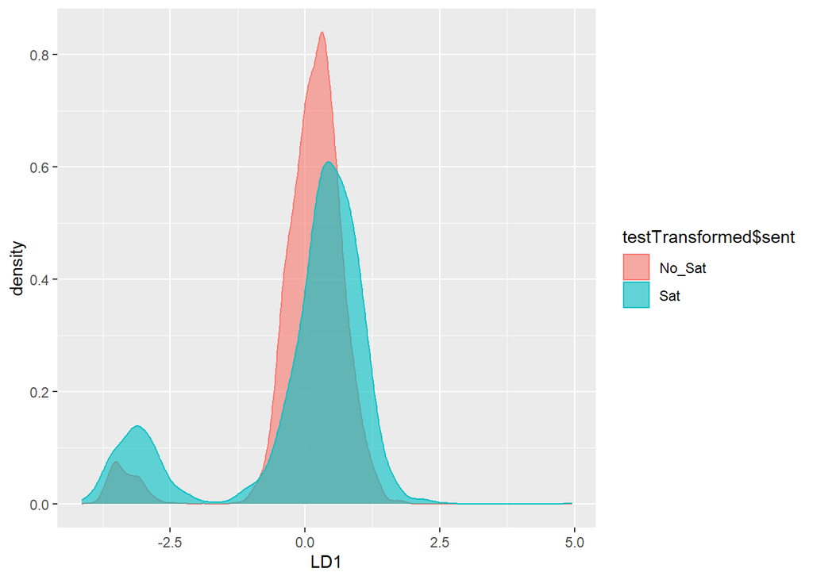

## 3.4 Comparison

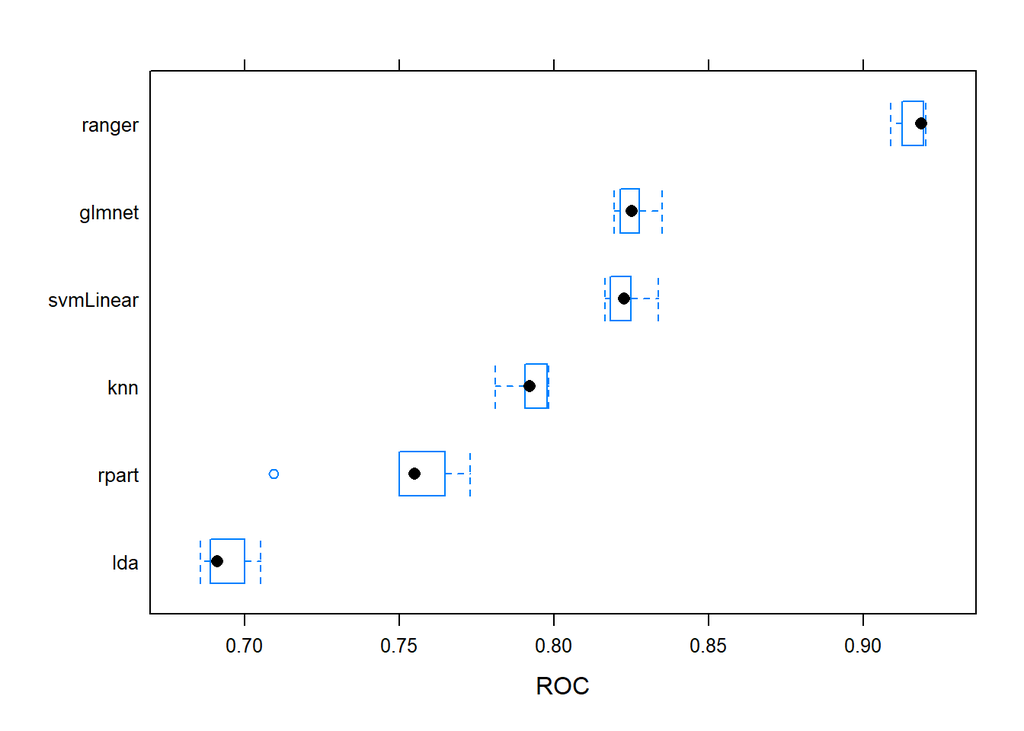

```r
model_list <- list(
  knn = knnfit_none,
  glmnet = glmnetfit,
  svmLinear = svm,
  rpart = decisiontTree,
  ranger = Rf_hyp_up,
  lda = lda.fit
)
resamps <- resamples(model_list)

bwplot(resamps, metric = "ROC")
```

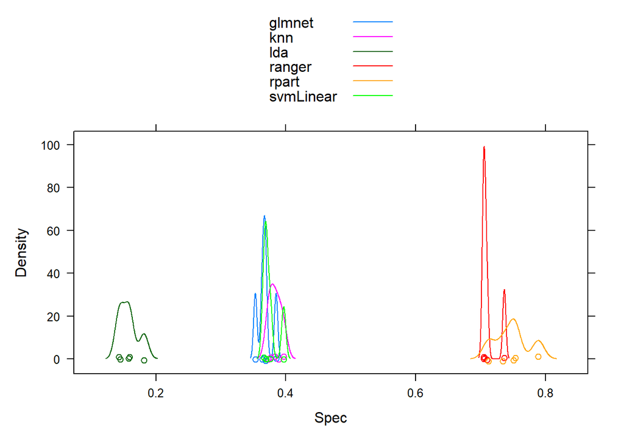

```r
densityplot(resamps,metric = "Spec",auto.key=TRUE)
```

# 4 Regression Models

I have chosen to do cross validation instead of bootstrap is very computationally heavy

## 4.1 Step-wise Linear Regression

```
## [1] 0.3821811
```

## 4.2 Linear Regression with regularization

```
## [1] 0.3751889
```

## 4.3 Random Forest

```
## [1] 0.3109432
```

## 4.4 Xgboost

```
## [1] 1.189124
```

## 4.5 Nueral Network

```
## [1] 0.265098
```

## 4.6 Comparison

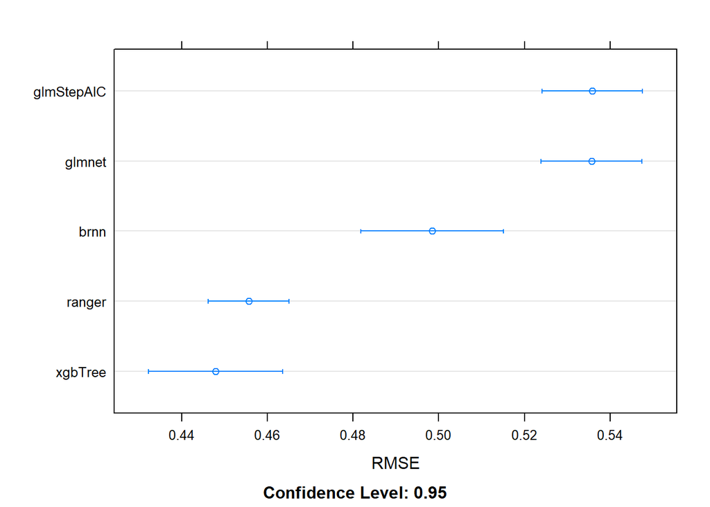

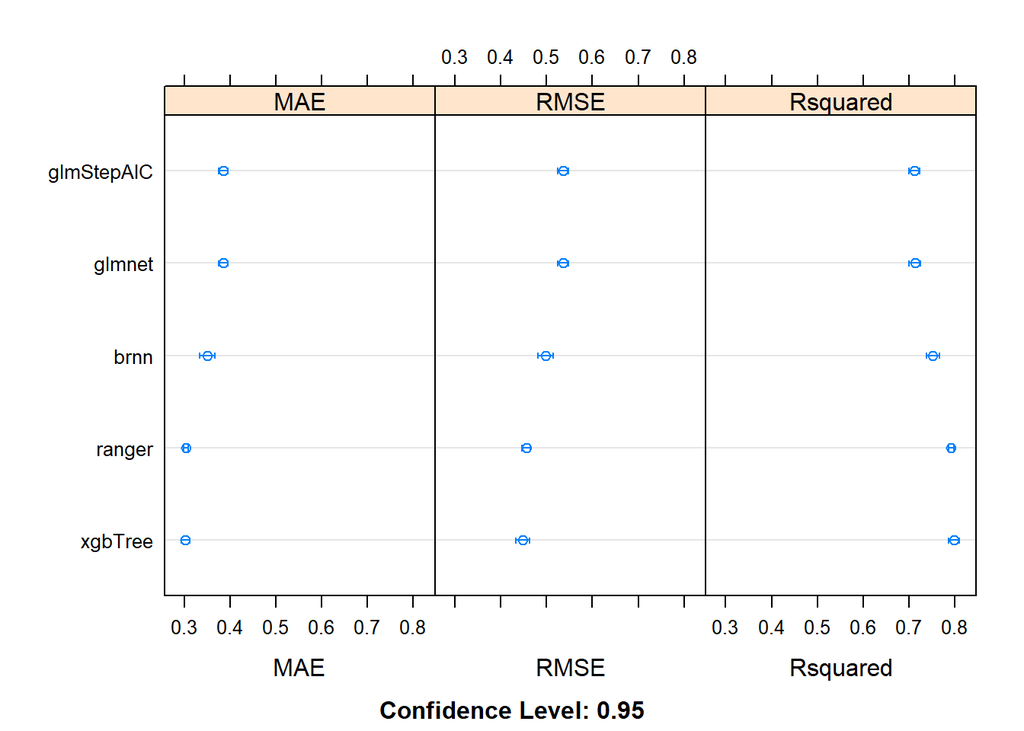